# Dreesales_analysis

```python
#Import the required Libraries.
import numpy as np
import pandas as pd
import matplotlib.pyplot as plt
import seaborn as sns
```

## Data Cleaning

### Data Reading & Data Types

```python
#Read the data in pandas
inp0= pd.read_csv(r"C:\Users\Sairam\Documents\Data_Analysis_Project\Data_Analysis_Project\Attribute DataSet.csv ")
inp1= pd.read_csv(r"C:\Users\Sairam\Documents\Data_Analysis_Project\Data_Analysis_Project\Dress Sales.csv ")
```

You have “Attribute DataSet” which contains a column named “Price”. Choose the correct statement from the following about its data type and variable type. . Integer type and numerical variable . Object type and categorical ordinal variable . Object type and categorical nominal variable . Float type and categorical variable.

Ans:object type and categerical ordinal variable. Because the price column follows the meaningful order or ranking. These ordinal variables are often used in surveys, questionnaires, and various types of assessments where participants are asked to express their preferences, opinions, or rankings.

There is another column in “Attribute DataSet” named as “Recommendation”, choose the correct statement about its data type and variable type.

- Integer type and categorical
- Object type and categorical
- Integer type and continuous numerical
- Object type only.

Which of the following column do you think are of no use in “Attribute DataSet”.

- Dress_ID
- Price
- Size and material
- NeckLine
- None of the above

Ans:Dress_Id. Because remaining price,size and material,neckline are more important than this.

```python
# Print the information about the attributes of inp0 and inp1.
inp0.shape
```

```
(479, 13)
```

```python
inp0.info()
```

```
<class 'pandas.core.frame.DataFrame'>
RangeIndex: 479 entries, 0 to 478
Data columns (total 13 columns):
 #   Column          Non-Null Count  Dtype
---  ------          --------------  -----
 0   Dress_ID        479 non-null    int64
 1   Style           479 non-null    object
 2   Price           477 non-null    object
 3   Rating          479 non-null    float64
 4   Size            479 non-null    object
 5   Season          477 non-null    object
 6   NeckLine        476 non-null    object
 7   SleeveLength    477 non-null    object
 8   Material        360 non-null    object
 9   FabricType      223 non-null    object
 10  Decoration      255 non-null    object
 11  Pattern Type    377 non-null    object
 12  Recommendation  479 non-null    int64
dtypes: float64(1), int64(2), object(10)
memory usage: 48.8+ KB
```

```python
inp0.head()
```

|  | Dress_ID | Style | Price | Rating | Size | Season | NeckLine | SleeveLength | Material | FabricType | Decoration | Pattern Type | Recommendation |
| --- | --- | --- | --- | --- | --- | --- | --- | --- | --- | --- | --- | --- | --- |
| 0 | 1006032852 | Sexy | Low | 4.6 | M | Summer | o-neck | sleevless | NaN | chiffon | ruffles | animal | 1 |
| 1 | 1212192089 | Casual | Low | 0.0 | L | Summer | o-neck | Petal | microfiber | NaN | ruffles | animal | 0 |
| 2 | 1190380701 | vintage | High | 0.0 | L | Automn | o-neck | full | polyster | NaN | NaN | print | 0 |
| 3 | 966005983 | Brief | Average | 4.6 | L | Spring | o-neck | full | silk | chiffon | embroidary | print | 1 |
| 4 | 876339541 | cute | Low | 4.5 | M | Summer | o-neck | butterfly | chiffonfabric | chiffon | bow | dot | 0 |

```python
inp0.tail()
```

|  | Dress_ID | Style | Price | Rating | Size | Season | NeckLine | SleeveLength | Material | FabricType | Decoration | Pattern Type | Recommendation |
| --- | --- | --- | --- | --- | --- | --- | --- | --- | --- | --- | --- | --- | --- |
| 474 | 990559192 | Brief | Average | 4.7 | M | winter | o-neck | halfsleeve | acrylic | chiffon | NaN | striped | 0 |
| 475 | 713391965 | Casual | Low | 4.7 | M | Spring | o-neck | full | polyster | NaN | NaN | solid | 1 |
| 476 | 532874347 | Casual | Average | 4.7 | M | Summer | v-neck | full | cotton | NaN | lace | solid | 1 |
| 477 | 655464934 | Casual | Average | 4.6 | L | winter | boat-neck | sleevless | silk | broadcloth | applique | print | 1 |
| 478 | 919930954 | Casual | Low | 4.4 | free | Summer | v-neck | short | cotton | Corduroy | lace | solid | 0 |

```python
inp1.head()
```

|  | Dress_ID | 29-08-2013 | 31-08-2013 | 09-02-2013 | 09-04-2013 | 09-06-2013 | 09-08-2013 | 09-10-2013 | 09-12-2013 | 14-09-2013 | ... | 24-09-2013 | 26-09-2013 | 28-09-2013 | 30-09-2013 | 10-02-2013 | 10-04-2013 | 10-06-2013 | 10-08-2013 | 10-10-2013 | 10-12-2013 |
| --- | --- | --- | --- | --- | --- | --- | --- | --- | --- | --- | --- | --- | --- | --- | --- | --- | --- | --- | --- | --- | --- |
| 0 | 1.006033e+09 | 2114 | 2274 | 2491 | 2660 | 2727 | 2887 | 2930 | 3119 | 3204 | ... | 3554 | 3624.0 | 3706 | 3746.0 | 3795.0 | 3832.0 | 3897 | 3923.0 | 3985.0 | 4048 |
| 1 | 1.212192e+09 | 151 | 275 | 570 | 750 | 813 | 1066 | 1164 | 1558 | 1756 | ... | 2710 | 2942.0 | 3258 | 3354.0 | 3475.0 | 3654.0 | 3911 | 4024.0 | 4125.0 | 4277 |
| 2 | 1.190381e+09 | 6 | 7 | 7 | 7 | 8 | 8 | 9 | 10 | 10 | ... | 11 | 11.0 | 11 | 11.0 | 11.0 | 11.0 | 11 | 11.0 | 11.0 | 11 |
| 3 | 9.660060e+08 | 1005 | 1128 | 1326 | 1455 | 1507 | 1621 | 1637 | 1723 | 1746 | ... | 1878 | 1892.0 | 1914 | 1924.0 | 1929.0 | 1941.0 | 1952 | 1955.0 | 1959.0 | 1963 |
| 4 | 8.763395e+08 | 996 | 1175 | 1304 | 1396 | 1432 | 1559 | 1570 | 1638 | 1655 | ... | 2032 | 2156.0 | 2252 | 2312.0 | 2387.0 | 2459.0 | 2544 | 2614.0 | 2693.0 | 2736 |

5 rows × 24 columns

```python
inp1.tail()
```

|  | Dress_ID | 29-08-2013 | 31-08-2013 | 09-02-2013 | 09-04-2013 | 09-06-2013 | 09-08-2013 | 09-10-2013 | 09-12-2013 | 14-09-2013 | ... | 24-09-2013 | 26-09-2013 | 28-09-2013 | 30-09-2013 | 10-02-2013 | 10-04-2013 | 10-06-2013 | 10-08-2013 | 10-10-2013 | 10-12-2013 |
| --- | --- | --- | --- | --- | --- | --- | --- | --- | --- | --- | --- | --- | --- | --- | --- | --- | --- | --- | --- | --- | --- |
| 474 | 990559192.0 | 0 | 0 | 0 | 60 | 62 | 64 | 65 | 67 | 68 | ... | 73 | 74.0 | 75 | 75.0 | 76.0 | 76.0 | 77 | 77.0 | 77.0 | 77 |
| 475 | 713391965.0 | 0 | 0 | 0 | 560 | 554 | 544 | 537 | 525 | 519 | ... | 400 | 388.0 | 360 | 364.0 | 372.0 | 377.0 | 380 | 382.0 | 384.0 | 285 |
| 476 | 532874347.0 | 0 | 0 | 0 | 734 | 728 | 726 | 715 | 694 | 690 | ... | 616 | 597.0 | 586 | 569.0 | 561.0 | 555.0 | 551 | 546.0 | 535.0 | 520 |
| 477 | 655464934.0 | 0 | 0 | 0 | 254 | 259 | 261 | 263 | 268 | 270 | ... | 257 | 256.0 | 255 | 254.0 | 253.0 | 250.0 | 249 | 249.0 | 249.0 | 248 |
| 478 | 919930954.0 | 0 | 0 | 0 | 538 | 545 | 558 | 563 | 578 | 585 | ... | 628 | 632.0 | 639 | 645.0 | 651.0 | 655.0 | 660 | 668.0 | 674.0 | 680 |

5 rows × 24 columns

```python
inp1.info()
```

```
<class 'pandas.core.frame.DataFrame'>
RangeIndex: 479 entries, 0 to 478
Data columns (total 24 columns):
 #   Column      Non-Null Count  Dtype
---  ------      --------------  -----
 0   Dress_ID    479 non-null    float64
 1   29-08-2013  479 non-null    int64
 2   31-08-2013  479 non-null    int64
 3   09-02-2013  479 non-null    int64
 4   09-04-2013  479 non-null    int64
 5   09-06-2013  479 non-null    int64
 6   09-08-2013  479 non-null    int64
 7   09-10-2013  479 non-null    int64
 8   09-12-2013  479 non-null    object
 9   14-09-2013  479 non-null    object
```

[output cut: 16 more lines]

```python
inp1.shape
```

```
(479, 24)
```

### Fixing the Rows and Columns

As you can see, there is a column in “Attribute Dataset” named as ‘Size’. This column contains the values in abbreviation format. Write a code in Python to convert the followings:

- M into “Medium”
- L into “Large”
- XL into “Extra large”
- free into “Free”
- S, s & small into “Small”.

Now once you are done with changes in the dataset, what is the value of the lowest percentage, the highest percentage and the percentage of Small size categories in the column named “Size”?

```python
# Column fixing, correcting size abbreviation. count the percentage of each size category in "Size" column.

# Convert size abbreviations to full names
size_mapping = {'M': 'Medium', 'L': 'Large', 'XL': 'Extra large', 'free': 'Free', 'S': 'Small', 's': 'Small', 'small': 'Small'}
inp0['Size'] = inp0['Size'].map(size_mapping)

# Count the occurrences of each size
size_counts = inp0['Size'].value_counts()

# Calculate the percentage of each size category
size_percentages = (size_counts / len(inp0)) * 100

# Display the results
result_df = pd.DataFrame({'Size': size_counts.index, 'Count': size_counts.values, 'Percentage': size_percentages.values})
print(result_df)

# Find the lowest, highest, and percentage of Small size categories
lowest_percentage = result_df['Percentage'].min()
highest_percentage = result_df['Percentage'].max()
percentage_small = result_df[result_df['Size'] == 'Small']['Percentage'].values[0]

print(f"\nLowest Percentage: {lowest_percentage}%")
print(f"Highest Percentage: {highest_percentage}%")
print(f"Percentage of Small size categories: {percentage_small}%")
```

```
          Size  Count  Percentage
0       Medium    171   35.699374
1         Free    165   34.446764
2        Large     93   19.415449
3        Small     36    7.515658
4  Extra large     14    2.922756

Lowest Percentage: 2.9227557411273484%
Highest Percentage: 35.699373695198325%
Percentage of Small size categories: 7.515657620041753%
```

```python
inp0.columns
```

```
Index(['Dress_ID', 'Style', 'Price', 'Rating', 'Size', 'Season', 'NeckLine',
       'SleeveLength', 'Material', 'FabricType', 'Decoration', 'Pattern Type',
       'Recommendation'],
      dtype='object')
```

```python
# Print the value counts of each category in "Size" column.
inp0.Size.value_counts()/inp0.Size.shape[0] *100.0
```

```
Size
Medium         35.699374
Free           34.446764
Large          19.415449
Small           7.515658
Extra large     2.922756
Name: count, dtype: float64
```

```python
inp1.dtypes
```

```
Dress_ID      float64
29-08-2013      int64
31-08-2013      int64
09-02-2013      int64
09-04-2013      int64
09-06-2013      int64
09-08-2013      int64
09-10-2013      int64
09-12-2013     object
14-09-2013     object
16-09-2013     object
18-09-2013     object
20-09-2013     object
22-09-2013     object
24-09-2013      int64
26-09-2013    float64
28-09-2013      int64
30-09-2013    float64
10-02-2013    float64
10-04-2013    float64
10-06-2013      int64
10-08-2013    float64
10-10-2013    float64
10-12-2013      int64
dtype: object
```

### Impute/Remove Missing values

```python
# Print the null count of each variables of inp0 and inp1.
inp0.isnull().sum()
```

```
Dress_ID            0
Style               0
Price               2
Rating              0
Size                0
Season              2
NeckLine            3
SleeveLength        2
Material          119
FabricType        256
Decoration        224
Pattern Type      102
Recommendation      0
dtype: int64
```

```python
inp1.isnull().sum()
```

```
Dress_ID        0
29-08-2013      0
31-08-2013      0
09-02-2013      0
09-04-2013      0
09-06-2013      0
09-08-2013      0
09-10-2013      0
09-12-2013      0
14-09-2013      0
16-09-2013      0
18-09-2013      0
20-09-2013      0
22-09-2013      0
24-09-2013      0
26-09-2013    222
28-09-2013      0
30-09-2013    257
10-02-2013    259
10-04-2013    258
10-06-2013      0
10-08-2013    255
10-10-2013    255
10-12-2013      0
dtype: int64
```

You are given another dataset named “Dress Sales”. Now if you observe the datatypes of the columns using ‘inp1.info()’ command, you can identify that there are certain columns defined as object data type though they primarily consist of numeric data.

Now if you try and convert these object data type columns into numeric data type(float), you will come across an error message. Try to correct this error.

```python
# Print the data types information of inp1 i.e. "Dress Sales" data.
inp1.info()
```

```
<class 'pandas.core.frame.DataFrame'>
RangeIndex: 479 entries, 0 to 478
Data columns (total 24 columns):
 #   Column      Non-Null Count  Dtype
---  ------      --------------  -----
 0   Dress_ID    479 non-null    float64
 1   29-08-2013  479 non-null    int64
 2   31-08-2013  479 non-null    int64
 3   09-02-2013  479 non-null    int64
 4   09-04-2013  479 non-null    int64
 5   09-06-2013  479 non-null    int64
 6   09-08-2013  479 non-null    int64
 7   09-10-2013  479 non-null    int64
 8   09-12-2013  479 non-null    object
 9   14-09-2013  479 non-null    object
```

[output cut: 16 more lines]

```python
# Try to convert the object type into float type of data. YOU GET ERROR MESSAGE.
inp1['16-09-2013']=inp1['16-09-2013'].astype(float)
```

[output not shown]

[output cut: 16 more lines]

[output not shown]

```python
# Do the required changes in the "Dress Sales" data set to get null values on string values.
object_columns = inp1.select_dtypes(include='object').columns
for col in object_columns:
    inp1[col] = pd.to_numeric(inp1[col], errors='coerce')
print(inp1.info())
```

```
<class 'pandas.core.frame.DataFrame'>
RangeIndex: 479 entries, 0 to 478
Data columns (total 24 columns):
 #   Column      Non-Null Count  Dtype
---  ------      --------------  -----
 0   Dress_ID    479 non-null    float64
 1   29-08-2013  479 non-null    int64
 2   31-08-2013  479 non-null    int64
 3   09-02-2013  479 non-null    int64
 4   09-04-2013  479 non-null    int64
 5   09-06-2013  479 non-null    int64
 6   09-08-2013  479 non-null    int64
 7   09-10-2013  479 non-null    int64
 8   09-12-2013  478 non-null    float64
 9   14-09-2013  478 non-null    float64
```

[output cut: 17 more lines]

```python
# Convert the object type columns in "Dress Sales" into float type of data type.
inp1['16-09-2013'] =pd.to_numeric(inp1['16-09-2013'], errors='coerce')
inp1.dtypes
```

```
Dress_ID      float64
29-08-2013      int64
31-08-2013      int64
09-02-2013      int64
09-04-2013      int64
09-06-2013      int64
09-08-2013      int64
09-10-2013      int64
09-12-2013    float64
14-09-2013    float64
16-09-2013    float64
18-09-2013    float64
20-09-2013    float64
22-09-2013    float64
24-09-2013      int64
26-09-2013    float64
28-09-2013      int64
30-09-2013    float64
10-02-2013    float64
10-04-2013    float64
10-06-2013      int64
10-08-2013    float64
10-10-2013    float64
10-12-2013      int64
dtype: object
```

When you see the null counts in “Dress Sales” dataset after performing all the operations that have been mentioned in jupyter notebook, you will find that there are some columns in “Dress Sales” data where there are more than 40% of missing values. Based on your understanding of dealing with missing values do the following steps.

```python
# Print the null percetange of each column of inp1.
inp1.isnull().mean()*100
```

```
Dress_ID       0.000000
29-08-2013     0.000000
31-08-2013     0.000000
09-02-2013     0.000000
09-04-2013     0.000000
09-06-2013     0.000000
09-08-2013     0.000000
09-10-2013     0.000000
09-12-2013     0.208768
14-09-2013     0.208768
16-09-2013     0.208768
18-09-2013     0.208768
20-09-2013     0.208768
22-09-2013     0.208768
24-09-2013     0.000000
26-09-2013    46.346555
28-09-2013     0.000000
30-09-2013    53.653445
10-02-2013    54.070981
10-04-2013    53.862213
10-06-2013     0.000000
10-08-2013    53.235908
10-10-2013    53.235908
10-12-2013     0.000000
dtype: float64
```

```python
# Drop the columns in "Dress Sales" which have more than 40% of missing values.
a=inp1.isnull().mean()*100
column=a[a>40].index
inp1=inp1.drop(columns=column)
inp1.isnull().sum()
```

```
Dress_ID      0
29-08-2013    0
31-08-2013    0
09-02-2013    0
09-04-2013    0
09-06-2013    0
09-08-2013    0
09-10-2013    0
09-12-2013    1
14-09-2013    1
16-09-2013    1
18-09-2013    1
20-09-2013    1
22-09-2013    1
24-09-2013    0
28-09-2013    0
10-06-2013    0
10-12-2013    0
dtype: int64
```

```python
inp1.columns
```

```
Index(['Dress_ID', '29-08-2013', '31-08-2013', '09-02-2013', '09-04-2013',
       '09-06-2013', '09-08-2013', '09-10-2013', '09-12-2013', '14-09-2013',
       '16-09-2013', '18-09-2013', '20-09-2013', '22-09-2013', '24-09-2013',
       '28-09-2013', '10-06-2013', '10-12-2013'],
      dtype='object')
```

You should categorise the dates into seasons in “Dress Sales” data to simplify the analysis according to the following criteria:

- June, July and August: Summer.
- September, October and November: Autumn.
- December, January and February: WInter.
- March, April and May: Spring.

```python
# Create the four seasons columns in inp1, according to the above criteria.

summer=(inp1[['29-08-2013','31-08-2013','09-06-2013','09-08-2013', '10-06-2013']].sum()).sum()
Winter = (inp1[['09-02-2013','10-12-2013']].sum()).sum()
Spring = (inp1['09-04-2013'].sum()).sum()
Autumn= ['09-10-2013', '14-09-2013', '16-09-2013', '18-09-2013', '20-09-2013', '22-09-2013', '24-09-2013', '28-09-2013']
inp1[Autumn] = inp1[Autumn].apply(pd.to_numeric, errors='coerce')
Autumn = inp1[Autumn].sum().sum()
print('summer:-',summer)
print('Autumn:-',Autumn)
print('Winter:-',Winter)
print('Spring:-',Spring)
```

```
summer:- 691907
Autumn:- 1363288.0
Winter:- 314990
Spring:- 143600
```

```python
import pandas as pd

# Simplified data creation
data = {'Date': ['29-08-2013', '31-08-2013', '09-02-2013', '09-04-2013',
                 '09-06-2013', '09-08-2013', '09-10-2013', '09-12-2013',
                 '14-09-2013', '16-09-2013', '18-09-2013', '20-09-2013',
                 '22-09-2013', '24-09-2013', '28-09-2013', '10-06-2013',
                 '10-12-2013']}
df = pd.DataFrame({'Date': pd.to_datetime(data['Date'], format='%d-%m-%Y')})

# Create a new 'Season' column based on the month
df['Season'] = df['Date'].dt.month.map({1: 'Winter', 2: 'Winter', 3: 'Spring',
                                       4: 'Spring', 5: 'Spring', 6: 'Summer',
                                       7: 'Summer', 8: 'Summer', 9: 'Autumn',
                                       10: 'Autumn', 11: 'Autumn', 12: 'Winter'})

# Display the DataFrame with the new 'Season' column
print(df.head(50))
```

```
         Date  Season
0  2013-08-29  Summer
1  2013-08-31  Summer
2  2013-02-09  Winter
3  2013-04-09  Spring
4  2013-06-09  Summer
5  2013-08-09  Summer
6  2013-10-09  Autumn
7  2013-12-09  Winter
8  2013-09-14  Autumn
9  2013-09-16  Autumn
10 2013-09-18  Autumn
11 2013-09-20  Autumn
12 2013-09-22  Autumn
13 2013-09-24  Autumn
14 2013-09-28  Autumn
15 2013-06-10  Summer
16 2013-12-10  Winter
```

```python
# calculate the sum of sales in each seasons in inp1 i.e. "Dress Sales".
inp1.sum()
```

```
Dress_ID      4.321739e+11
29-08-2013    9.488300e+04
31-08-2013    1.004830e+05
09-02-2013    1.070810e+05
09-04-2013    1.436000e+05
09-06-2013    1.459730e+05
09-08-2013    1.516200e+05
09-10-2013    1.533280e+05
09-12-2013    1.596930e+05
14-09-2013    1.627920e+05
16-09-2013    1.653180e+05
18-09-2013    1.678330e+05
20-09-2013    1.723510e+05
22-09-2013    1.764140e+05
24-09-2013    1.786380e+05
28-09-2013    1.866140e+05
10-06-2013    1.989480e+05
10-12-2013    2.079090e+05
dtype: float64
```

Now let's merge inp1 with inp0 with left join manner, so that the information of inp0 should remain intact.

```python
inp1['Spring'] = inp1.apply(lambda x: x['09-04-2013'], axis=1)

inp1['Summer'] = inp1.apply(lambda x: x['29-08-2013'] + x['31-08-2013']+ x['09-06-2013']+ x['09-08-2013']+ x['10-06-2013'], axis=1)

inp1['Winter'] = inp1[['09-02-2013', '09-12-2013', '10-12-2013']].sum(axis=1)

inp1['Autumn'] = inp1[['09-10-2013', '14-09-2013', '16-09-2013', '18-09-2013', '20-09-2013', '22-09-2013', '24-09-2013', '28-09-2013']].sum(axis=1, skipna=True)
```

```python
# Merge inp0 with inp1 into inp0. this is also called left merge.
x = pd.merge(left=inp0,right=inp1, how='left', left_on='Dress_ID', right_on='Dress_ID')
x.head()
```

|  | Dress_ID | Style | Price | Rating | Size | Season | NeckLine | SleeveLength | Material | FabricType | ... | 20-09-2013 | 22-09-2013 | 24-09-2013 | 28-09-2013 | 10-06-2013 | 10-12-2013 | Spring | Summer | Winter | Autumn |
| --- | --- | --- | --- | --- | --- | --- | --- | --- | --- | --- | --- | --- | --- | --- | --- | --- | --- | --- | --- | --- | --- |
| 0 | 1006032852 | Sexy | Low | 4.6 | Medium | Summer | o-neck | sleevless | NaN | chiffon | ... | 3386.0 | 3479.0 | 3554 | 3706 | 3897 | 4048 | 2660.0 | 13899.0 | 9658.0 | 26857.0 |
| 1 | 1212192089 | Casual | Low | 0.0 | Large | Summer | o-neck | Petal | microfiber | NaN | ... | 2106.0 | 2454.0 | 2710 | 3258 | 3911 | 4277 | 750.0 | 6216.0 | 6405.0 | 17311.0 |
| 2 | 1190380701 | vintage | High | 0.0 | Large | Automn | o-neck | full | polyster | NaN | ... | 10.0 | 11.0 | 11 | 11 | 11 | 11 | 7.0 | 40.0 | 28.0 | 82.0 |
| 3 | 966005983 | Brief | Average | 4.6 | Large | Spring | o-neck | full | silk | chiffon | ... | 1812.0 | 1845.0 | 1878 | 1914 | 1952 | 1963 | 1455.0 | 7213.0 | 5012.0 | 14411.0 |
| 4 | 876339541 | cute | Low | 4.5 | Medium | Summer | o-neck | butterfly | chiffonfabric | chiffon | ... | 1824.0 | 1919.0 | 2032 | 2252 | 2544 | 2736 | 1396.0 | 7706.0 | 5678.0 | 14676.0 |

5 rows × 34 columns

```python
# Now Drop the Date columns from inp0 as it is already combined into four seasons.
date_columns_to_drop = x.columns[(x.columns >= '29-08-2013') & (x.columns <= '10-12-2013')]

# Drop the identified columns from x
x.drop(date_columns_to_drop, axis=1, inplace=True)
x
```

|  | Dress_ID | Style | Price | Rating | Size | Season | NeckLine | SleeveLength | Material | FabricType | ... | 20-09-2013 | 22-09-2013 | 24-09-2013 | 28-09-2013 | 10-06-2013 | 10-12-2013 | Spring | Summer | Winter | Autumn |
| --- | --- | --- | --- | --- | --- | --- | --- | --- | --- | --- | --- | --- | --- | --- | --- | --- | --- | --- | --- | --- | --- |
| 0 | 1006032852 | Sexy | Low | 4.6 | Medium | Summer | o-neck | sleevless | NaN | chiffon | ... | 3386.0 | 3479.0 | 3554 | 3706 | 3897 | 4048 | 2660.0 | 13899.0 | 9658.0 | 26857.0 |
| 1 | 1212192089 | Casual | Low | 0.0 | Large | Summer | o-neck | Petal | microfiber | NaN | ... | 2106.0 | 2454.0 | 2710 | 3258 | 3911 | 4277 | 750.0 | 6216.0 | 6405.0 | 17311.0 |
| 2 | 1190380701 | vintage | High | 0.0 | Large | Automn | o-neck | full | polyster | NaN | ... | 10.0 | 11.0 | 11 | 11 | 11 | 11 | 7.0 | 40.0 | 28.0 | 82.0 |
| 3 | 966005983 | Brief | Average | 4.6 | Large | Spring | o-neck | full | silk | chiffon | ... | 1812.0 | 1845.0 | 1878 | 1914 | 1952 | 1963 | 1455.0 | 7213.0 | 5012.0 | 14411.0 |
| 4 | 876339541 | cute | Low | 4.5 | Medium | Summer | o-neck | butterfly | chiffonfabric | chiffon | ... | 1824.0 | 1919.0 | 2032 | 2252 | 2544 | 2736 | 1396.0 | 7706.0 | 5678.0 | 14676.0 |
| ... | ... | ... | ... | ... | ... | ... | ... | ... | ... | ... | ... | ... | ... | ... | ... | ... | ... | ... | ... | ... | ... |
| 474 | 990559192 | Brief | Average | 4.7 | Medium | winter | o-neck | halfsleeve | acrylic | chiffon | ... | 72.0 | 73.0 | 73 | 75 | 77 | 77 | 60.0 | 203.0 | 144.0 | 565.0 |
| 475 | 713391965 | Casual | Low | 4.7 | Medium | Spring | o-neck | full | polyster | NaN | ... | 492.0 | 480.0 | 400 | 360 | 380 | 285 | 560.0 | 1478.0 | 810.0 | 3800.0 |
| 476 | 532874347 | Casual | Average | 4.7 | Medium | Summer | v-neck | full | cotton | NaN | ... | 665.0 | 658.0 | 616 | 586 | 551 | 520 | 734.0 | 2005.0 | 1214.0 | 5290.0 |
| 477 | 655464934 | Casual | Average | 4.6 | Large | winter | boat-neck | sleevless | silk | broadcloth | ... | 264.0 | 264.0 | 257 | 255 | 249 | 248 | 254.0 | 769.0 | 516.0 | 2117.0 |
| 478 | 919930954 | Casual | Low | 4.4 | Free | Summer | v-neck | short | cotton | Corduroy | ... | 605.0 | 619.0 | 628 | 639 | 660 | 680 | 538.0 | 1763.0 | 1258.0 | 4828.0 |

479 rows × 34 columns

```python
import pandas as pd
# Assuming inp0 is your DataFrame with datetime columns
inp0 = pd.DataFrame({
    'Date': pd.date_range(start='2022-01-01', periods=10, freq='D'),
    'Value1': [1, 2, 3, 4, 5, 6, 7, 8, 9, 10],
    'Value2': [10, 9, 8, 7, 6, 5, 4, 3, 2, 1]
})

# Convert 'Date' column to datetime if not already in datetime format
inp0['Date'] = pd.to_datetime(inp0['Date'])

# Drop columns within the specified date range
date_range_to_drop = pd.date_range('2013-08-29', '2013-12-10')
inp0.drop(columns=date_range_to_drop.intersection(inp0.columns), inplace=True)

# Check for null values
null_values = inp0.isnull().sum()

print(null_values)
```

```
Date      0
Value1    0
Value2    0
dtype: int64
```

Print the null count of inp0 to get the idea about the missing values in data set.

```python
# Print the null count of each columns in inp0 dataframe i.e. combined data frame of inp0 and inp1 without date columns
inp0.isnull().sum()
```

```
Date      0
Value1    0
Value2    0
dtype: int64
```

Type-2: Missing values are large in numbers (more than 15%): Material, FabricType, Decoration and Pattern Type.

```python
# Deal with the missing values of Type-1 columns: Price, Season, NeckLine, SleeveLength, Winter and Autumn.
columns_to_fill = ['Season', 'NeckLine', 'SleeveLength']
for column in columns_to_fill:
    if column in inp0.columns:
        inp0[column].fillna(inp0[column].mode()[0], inplace=True)
    if column in inp1.columns:
        inp1[column].fillna(inp1[column].mode()[0], inplace=True)

# Deal with the missing values of Type-2 columns: Winter and Autumn.
columns_to_fill = ['Winter', 'Autumn']
for column in columns_to_fill:
    if column in inp0.columns:
        inp0[column].fillna(inp0[column].mode()[0], inplace=True)
    if column in inp1.columns:
        inp1[column].fillna(inp1[column].mode()[0], inplace=True)

# Display the first few rows of inp0 DataFrame
inp0.head()
```

|  | Date | Value1 | Value2 |
| --- | --- | --- | --- |
| 0 | 2022-01-01 | 1 | 10 |
| 1 | 2022-01-02 | 2 | 9 |
| 2 | 2022-01-03 | 3 | 8 |
| 3 | 2022-01-04 | 4 | 7 |
| 4 | 2022-01-05 | 5 | 6 |

```python
inp1.head()
```

|  | Dress_ID | 29-08-2013 | 31-08-2013 | 09-02-2013 | 09-04-2013 | 09-06-2013 | 09-08-2013 | 09-10-2013 | 09-12-2013 | 14-09-2013 | ... | 20-09-2013 | 22-09-2013 | 24-09-2013 | 28-09-2013 | 10-06-2013 | 10-12-2013 | Spring | Summer | Winter | Autumn |
| --- | --- | --- | --- | --- | --- | --- | --- | --- | --- | --- | --- | --- | --- | --- | --- | --- | --- | --- | --- | --- | --- |
| 0 | 1.006033e+09 | 2114 | 2274 | 2491 | 2660 | 2727 | 2887 | 2930 | 3119.0 | 3204.0 | ... | 3386.0 | 3479.0 | 3554 | 3706 | 3897 | 4048 | 2660.0 | 13899.0 | 9658.0 | 26857.0 |
| 1 | 1.212192e+09 | 151 | 275 | 570 | 750 | 813 | 1066 | 1164 | 1558.0 | 1756.0 | ... | 2106.0 | 2454.0 | 2710 | 3258 | 3911 | 4277 | 750.0 | 6216.0 | 6405.0 | 17311.0 |
| 2 | 1.190381e+09 | 6 | 7 | 7 | 7 | 8 | 8 | 9 | 10.0 | 10.0 | ... | 10.0 | 11.0 | 11 | 11 | 11 | 11 | 7.0 | 40.0 | 28.0 | 82.0 |
| 3 | 9.660060e+08 | 1005 | 1128 | 1326 | 1455 | 1507 | 1621 | 1637 | 1723.0 | 1746.0 | ... | 1812.0 | 1845.0 | 1878 | 1914 | 1952 | 1963 | 1455.0 | 7213.0 | 5012.0 | 14411.0 |
| 4 | 8.763395e+08 | 996 | 1175 | 1304 | 1396 | 1432 | 1559 | 1570 | 1638.0 | 1655.0 | ... | 1824.0 | 1919.0 | 2032 | 2252 | 2544 | 2736 | 1396.0 | 7706.0 | 5678.0 | 14676.0 |

5 rows × 22 columns

```python
# Deal with the missing values for Type-2 columns: Material, FabricType, Decoration, and Pattern Type.
columns_to_fill_type2 = ['Material', 'FabricType', 'Decoration', 'Pattern Type']
for column in columns_to_fill_type2:
    if column in inp0.columns:
        inp0[column].fillna(inp0[column].mode()[0], inplace=True)

# Display the first few rows of inp0 DataFrame
inp0.head()
```

|  | Date | Value1 | Value2 |
| --- | --- | --- | --- |
| 0 | 2022-01-01 | 1 | 10 |
| 1 | 2022-01-02 | 2 | 9 |
| 2 | 2022-01-03 | 3 | 8 |
| 3 | 2022-01-04 | 4 | 7 |
| 4 | 2022-01-05 | 5 | 6 |

```python
inp0.columns
```

```
Index(['Date', 'Value1', 'Value2'], dtype='object')
```

### Standardise value

In the given dataset, there are certain discrepancies with the categorical names such as irregular spellings. Choose the correct option of columns with irregular categories and update them.

- Season, NeckLine
- Price, Material
- fabricType, Decoration
- Season, SleeveLength

```python
#correcting the spellings.
x.Season= x.Season.replace('Automn', "Autumn")

x.Season= x.Season.replace('spring', "Spring")

x.Season= x.Season.replace('winter', "Winter")
x.head()
```

|  | Dress_ID | Style | Price | Rating | Size | Season | NeckLine | SleeveLength | Material | FabricType | ... | 20-09-2013 | 22-09-2013 | 24-09-2013 | 28-09-2013 | 10-06-2013 | 10-12-2013 | Spring | Summer | Winter | Autumn |
| --- | --- | --- | --- | --- | --- | --- | --- | --- | --- | --- | --- | --- | --- | --- | --- | --- | --- | --- | --- | --- | --- |
| 0 | 1006032852 | Sexy | Low | 4.6 | Medium | Summer | o-neck | sleevless | NaN | chiffon | ... | 3386.0 | 3479.0 | 3554 | 3706 | 3897 | 4048 | 2660.0 | 13899.0 | 9658.0 | 26857.0 |
| 1 | 1212192089 | Casual | Low | 0.0 | Large | Summer | o-neck | Petal | microfiber | NaN | ... | 2106.0 | 2454.0 | 2710 | 3258 | 3911 | 4277 | 750.0 | 6216.0 | 6405.0 | 17311.0 |
| 2 | 1190380701 | vintage | High | 0.0 | Large | Autumn | o-neck | full | polyster | NaN | ... | 10.0 | 11.0 | 11 | 11 | 11 | 11 | 7.0 | 40.0 | 28.0 | 82.0 |
| 3 | 966005983 | Brief | Average | 4.6 | Large | Spring | o-neck | full | silk | chiffon | ... | 1812.0 | 1845.0 | 1878 | 1914 | 1952 | 1963 | 1455.0 | 7213.0 | 5012.0 | 14411.0 |
| 4 | 876339541 | cute | Low | 4.5 | Medium | Summer | o-neck | butterfly | chiffonfabric | chiffon | ... | 1824.0 | 1919.0 | 2032 | 2252 | 2544 | 2736 | 1396.0 | 7706.0 | 5678.0 | 14676.0 |

5 rows × 34 columns

```python
x.columns
```

```
Index(['Dress_ID', 'Style', 'Price', 'Rating', 'Size', 'Season', 'NeckLine',
       'SleeveLength', 'Material', 'FabricType', 'Decoration', 'Pattern Type',
       'Recommendation', '29-08-2013', '31-08-2013', '09-02-2013',
       '09-04-2013', '09-06-2013', '09-08-2013', '09-10-2013', '09-12-2013',
       '14-09-2013', '16-09-2013', '18-09-2013', '20-09-2013', '22-09-2013',
       '24-09-2013', '28-09-2013', '10-06-2013', '10-12-2013', 'Spring',
       'Summer', 'Winter', 'Autumn'],
      dtype='object')
```

There is a column named ‘Style’ in ‘Attribute Dataset’ which consists of the different style categories of the women apparels. Certain categories whose total sale is less than 50000 across all the seasons is considered under one single category as ‘Others’.

Which of the following categories in ‘Style’ column can be grouped into ‘Others’ category? and perform the grouping operation in the notebook for further analysis.

- Flare, fashion
- Novelty, bohemian
- OL, fashion, work
- Novelty, fashion, Flare

```python
# Group "Style" categories into "Others" which have less than 50000 sales across all the seasons.
#inp0['total'] = inp0['Summer'] + inp0['Autumn'] + inp0['Winter'] + inp0['Spring']
x['total'] = x[['Summer', 'Autumn', 'Winter', 'Spring']].sum(axis=1)

# Calculate total sales for each style
style_sales = x.groupby('Style')['total'].sum()

# Identify styles with total sales less than 50000
styles_to_group = style_sales[style_sales < 50000].index.tolist()

# Replace those styles with 'Others' using boolean indexing
x.loc[x['Style'].isin(styles_to_group), 'Style'] = 'Others'

# Check the updated DataFrame
x['Style'].unique()
```

```
array(['Sexy', 'Casual', 'vintage', 'Brief', 'cute', 'bohemian', 'Others',
       'party', 'sexy', 'work'], dtype=object)
```

```python
x.columns
```

[output not shown]

```python
# Assuming 'total' is the column representing total sales in your DataFrame
# 'Style' is the column containing style categories
# Assuming 'total' is the column representing total sales in your DataFrame
# 'Style' is the column containing style categories

# Calculate total sales for each style
style_sales = x.groupby('Style')['total'].sum()

# Identify styles with total sales less than 50000
styles_to_group = style_sales[style_sales < 50000].index.tolist()

# Replace those styles with 'Others' using boolean indexing
x.loc[x['Style'].isin(styles_to_group), 'Style'] = 'Others'

# Check the unique values in the 'Style' column
print(x['Style'].unique())
```

```
['Sexy' 'Casual' 'vintage' 'Brief' 'cute' 'bohemian' 'Others' 'party'
 'sexy' 'work']
```

```python
inp0.head()
```

|  | Date | Value1 | Value2 |
| --- | --- | --- | --- |
| 0 | 2022-01-01 | 1 | 10 |
| 1 | 2022-01-02 | 2 | 9 |
| 2 | 2022-01-03 | 3 | 8 |
| 3 | 2022-01-04 | 4 | 7 |
| 4 | 2022-01-05 | 5 | 6 |

What is the percentage of “cute” and “Others” category in “Style” column in “Attribute DataSet” respectively?

- 46%, 5%
- 9%, 2.1%
- 2.1%, 5%
- 13.8%, 9%

```python
# Calculate the percentage of each categories in the "Style" variable.
# Calculate the percentage of each category in the "Style" variable.
style_percentage = x['Style'].value_counts(normalize=True) * 100

# Print or use the results as needed
print("Percentage of each category in the 'Style' variable:")
print(style_percentage)
```

```
Percentage of each category in the 'Style' variable:
Style
Casual      45.720251
Sexy        13.778706
party       10.647182
cute         9.185804
vintage      5.219207
bohemian     4.801670
Brief        3.549061
work         3.549061
Others       2.087683
sexy         1.461378
Name: proportion, dtype: float64
```

Similarly Club Neckline, SLeeve length categories into "Others" which have less than 50000 sales across all the seasons.

```python
# Group "Neckline" categories into "Others" which have less than 50000 sales across all the seasons.

# Assuming 'total' is the column representing total sales in your DataFrame
# 'NeckLine' is the column containing neckline categories

# Calculate total sales for each neckline category
neckline_sales = x.groupby('NeckLine')['total'].sum()

# Identify neckline categories with total sales less than 50000
necklines_to_group = neckline_sales[neckline_sales < 50000].index.tolist()

# Replace those neckline categories with 'Others' using boolean indexing
x.loc[x['NeckLine'].isin(necklines_to_group), 'NeckLine'] = 'Others'

# Check the unique values in the 'NeckLine' column
print(x['NeckLine'].unique())
```

```
['o-neck' 'v-neck' 'boat-neck' 'Others' 'ruffled' 'turndowncollor'
 'slash-neck' nan]
```

```python
# Group "Sleeve length" categories into "Others" which have less than 50000 sales across all the seasons.

# Assuming 'total' is the column representing total sales in your DataFrame
# 'SleeveLength' is the column containing sleeve length categories

# Calculate total sales for each sleeve length category
sleeve_length_sales = x.groupby('SleeveLength')['total'].sum()

# Identify sleeve length categories with total sales less than 50000
sleeve_lengths_to_group = sleeve_length_sales[sleeve_length_sales < 50000].index.tolist()

# Replace those sleeve length categories with 'Others' using boolean indexing
x.loc[x['SleeveLength'].isin(sleeve_lengths_to_group), 'SleeveLength'] = 'Others'

# Check the unique values in the 'SleeveLength' column
print(x['SleeveLength'].unique())
```

```
['sleevless' 'Others' 'full' 'short' 'threequarter' 'halfsleeve' nan]
```

Club material, fabrictype, patterntype and decoration categories into "Others" which have less than 25000 sales across all the seasons

```python
# Group "material" categories into "Others" which have less than 25000 sales across all the seasons.
# Assuming 'total' is the column representing total sales in your DataFrame
# 'Material' is the column containing material categories

# Calculate total sales for each material category
material_sales = x.groupby('Material')['total'].sum()

# Identify material categories with total sales less than 25000
materials_to_group = material_sales[material_sales < 25000].index.tolist()

# Replace those material categories with 'Others' using boolean indexing
x.loc[x['Material'].isin(materials_to_group), 'Material'] = 'Others'

# Check the unique values in the 'Material' column
print(x['Material'].unique())
```

```
[nan 'microfiber' 'polyster' 'silk' 'chiffonfabric' 'cotton' 'nylon'
 'Others' 'milksilk' 'rayon' 'mix']
```

```python
# Group "fabric type" categories into "Others" which have less than 25000 sales across all the seasons.
# Assuming 'total' is the column representing total sales in your DataFrame
# 'FabricType' is the column containing fabric type categories

# Calculate total sales for each fabric type category
fabric_type_sales = x.groupby('FabricType')['total'].sum()

# Identify fabric type categories with total sales less than 25000
fabric_types_to_group = fabric_type_sales[fabric_type_sales < 25000].index.tolist()

# Replace those fabric type categories with 'Others' using boolean indexing
x.loc[x['FabricType'].isin(fabric_types_to_group), 'FabricType'] = 'Others'

# Check the unique values in the 'FabricType' column
print(x['FabricType'].unique())
```

```
['chiffon' nan 'broadcloth' 'jersey' 'Others' 'worsted' 'shiffon']
```

```python
# Group "patern type" categories into "Others" which have less than 25000 sales across all the seasons.
# Assuming 'total' is the column representing total sales in your DataFrame
# 'Pattern Type' is the column containing pattern type categories

# Calculate total sales for each pattern type category
pattern_type_sales = x.groupby('Pattern Type')['total'].sum()

# Identify pattern type categories with total sales less than 25000
pattern_types_to_group = pattern_type_sales[pattern_type_sales < 25000].index.tolist()

# Replace those pattern type categories with 'Others' using boolean indexing
x.loc[x['Pattern Type'].isin(pattern_types_to_group), 'Pattern Type'] = 'Others'

# Check the unique values in the 'Pattern Type' column
print(x['Pattern Type'].unique())
```

```
['animal' 'print' 'dot' 'solid' nan 'patchwork' 'striped' 'geometric'
 'Others' 'leopard']
```

```python
# Group "decoration" categories into "Others" which have less than 25000 sales across all the seasons.
# Assuming 'total' is the column representing total sales in your DataFrame
# 'Decoration' is the column containing decoration categories

# Calculate total sales for each decoration category
decoration_sales = x.groupby('Decoration')['total'].sum()

# Identify decoration categories with total sales less than 25000
decorations_to_group = decoration_sales[decoration_sales < 25000].index.tolist()

# Replace those decoration categories with 'Others' using boolean indexing
x.loc[x['Decoration'].isin(decorations_to_group), 'Decoration'] = 'Others'

# Check the unique values in the 'Decoration' column
print(x['Decoration'].unique())
```

```
['ruffles' nan 'embroidary' 'bow' 'beading' 'lace' 'sashes' 'hollowout'
 'Others' 'sequined' 'applique']
```

### Caregorical Ordered Univariate Analysis

Which of the following is an unordered variable in “Attribute DataSet”.

- Style
- Price
- Season
- Size

Ans:style

### Numerical variable Univariate analysis:

What is the approximate difference between the maximum value and 75th percentile in “Autumn” column.

- Approx 54000
- Approx 55000
- Approx 52000
- Approx 50000

Ans:52000

```python
Autumn_max = inp1['Autumn'].max()
Autumn_75th_percentile = x['Autumn'].quantile(0.75)

# Calculate the difference
difference = Autumn_max - Autumn_75th_percentile

# Print or use the result as needed
print(f"Approximate difference between Autumn max and 75th percentile: {difference}")
```

```
Approximate difference between Autumn max and 75th percentile: 52406.0
```

```python
# Describe the numerical variale: "Autumn".

x['Autumn'].describe()
```

```
count      479.000000
mean      2846.112735
std       5004.985872
min          1.000000
25%        410.500000
50%       1334.000000
75%       3126.000000
max      55532.000000
Name: Autumn, dtype: float64
```

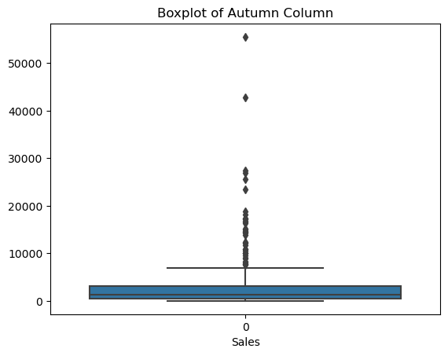

```python
# plot the boxplot of "Autumn" column.

autumn_column = x['Autumn']
# Create a boxplot
sns.boxplot(x.Autumn)
plt.title('Boxplot of Autumn Column')
plt.xlabel('Sales')
plt.show()
```

Which of the following season has the highest difference between the maximum value and 99th quantile of sales?

- Winter
- Summer
- Spring
- Autumn

Ans:Autumn

```python
# Find the maximum and 50th percentile of winter season.
winter_Sales = x['Winter'].to_numpy()

# Calculate the maximum temperature
max_Sales = np.max(winter_Sales)

# Calculate the 50th percentile (median) temperature
percentile_50 = np.percentile(winter_Sales, 50)

# Print the results
print(f"Maximum Sales: {max_Sales}")
print(f"50th percentile Sales: {percentile_50}")
```

```
Maximum Sales: 20388.0
50th percentile Sales: 402.0
```

```python
# Find the maximum and 50th percentile of Summer season.

winter_Sales = x['Summer'].to_numpy()

# Calculate the maximum temperature
max_Sales = np.max(winter_Sales)

# Calculate the 50th percentile (median) temperature
percentile_50 = np.percentile(winter_Sales, 50)

# Print the results
print(f"Maximum Sales: {max_Sales}")
print(f"50th percentile Sales: {percentile_50}")
```

```
Maximum Sales: 35577.0
50th percentile Sales: 518.0
```

```python
# Find the maximum and 50th percentile of Spring season.
winter_Sales = x['Spring'].to_numpy()

# Calculate the maximum temperature
max_Sales = np.max(winter_Sales)

# Calculate the 50th percentile (median) temperature
percentile_50 = np.percentile(winter_Sales, 50)

# Print the results
print(f"Maximum Sales: {max_Sales}")
print(f"50th percentile Sales: {percentile_50}")
```

```
Maximum Sales: 7374.0
50th percentile Sales: 110.0
```

```python
# Find the maximum and 50th percentile of Autumn season.

winter_Sales= x['Autumn'].to_numpy()

# Calculate the maximum temperature
max_Sales = np.max(winter_Sales)

# Calculate the 50th percentile (median) temperature
percentile_50 = np.percentile(winter_Sales, 50)

# Print the results
print(f"Maximum Sales: {max_Sales}")
print(f"50th percentile Sales: {percentile_50}")
```

```
Maximum Sales: 55532.0
50th percentile Sales: 1334.0
```